# Class 4 - In class exercises

Hari Subhash

Date created: 2019-03-20

**CHEATSHEETS**

1. [Data visualization](https://github.com/rstudio/cheatsheets/blob/master/data-visualization-2.1.pdf)
2. [Data Manipulation](https://github.com/rstudio/cheatsheets/blob/master/data-transformation.pdf)

**KEYBOARD SHORTCUTS**:

1. Assignment operator (<-) is `Alt+-` for Windows and `Option+-` for Mac
2. Insert new code chunk `Ctrl+Alt+I` for Windows and `Command+Option+I` for Mac
3. Run a line of code `Ctrl+Enter` for Windows and `Command+Enter` for Mac
4. Run all the code within a chunk `Ctrl+Shift+Enter` for Windows and `Command+Shift+Enter` for Mac
5. Insert a pipe operator (%>%) `Ctrl+Shift+M` for Windows and `Command+Shift+M` for Mac

## Task Set 1: Recap + Factors

1. Filter all departure delays that were between 10 and 20 minutes from LGA in 2013
2. Use `group_by()` and `filter()` to find the flights that had the greatest delay for each month in 2013.
3. Write two lines on why it is important to ungroup a grouped dataset (once your are done with the grouping operations).
4. Look at the documentation for `weekdays()`. Use it on the `time_hour` column inside a `mutate()` to create a new column called `dayName` that records the day of the week that a flight took off. Save this new dataset as `flightsWeek`.

```r
library(tidyverse); library(nycflights13)
flightsWeek <- flights %>%
    mutate(dayName = weekdays(time_hour))
```

5. Convert this into a factor variable called `fctDayNames` using `factor(flightsWeek$dayName)`. Display it using `table(fctDayNames)`.

```r
fctDayNames <- factor(flightsWeek$dayName)
table(fctDayNames)
```

```
fctDayNames
   Friday    Monday  Saturday    Sunday  Thursday   Tuesday Wednesday
    50308     50690     38720     46357     50219     50422     50060
```

6. Use `levels()` on `fctDayNames` to order the levels of the factors to the following order: c(“Sunday”, “Monday”, “Tuesday”, “Wednesday”, “Thursday”, “Friday”, “Saturday”). Show the output using `table(fctDayNames)` INCORRECT USE OF LEVELS FUNCTION.
7. Now combine the previous two steps in a `factor()` function by setting the value of the levels argument within it, also set the labels argument to c(“Sun”, “Mon”, “Tue”, “Wed”, “Thu”, “Fri”, “Sat”). Save this as `cleanFctDayNames` See `?factor`. Show output using `table(cleanFctDayNames)`. Observe the differences in output between 5, 6 and 7.

```r
cleanFctDayNames <- factor(flightsWeek$dayName, levels = c("Sunday", "Monday", "Tuesday", "Wednesday", "Thursday", "Friday", "Saturday"), labels = c("Sun", "Mon", "Tue", "Wed", "Thu", "Fri", "Sat"))
table(cleanFctDayNames)
```

```
cleanFctDayNames
  Sun   Mon   Tue   Wed   Thu   Fri   Sat
46357 50690 50422 50060 50219 50308 38720
```

## Task Set 2: Create simple charts

1. Create a histogram of arrival delay.

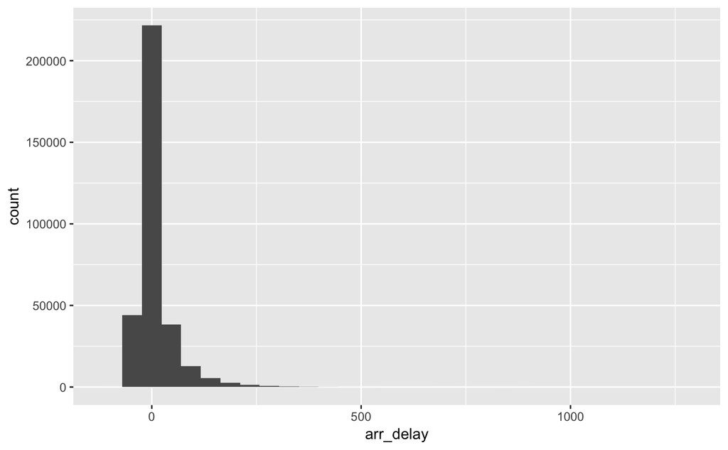

2. Change the statistic for the histogram from the default of “count” to “density” and plot again. POOR QUESTION

```r
ggplot(flights, aes(arr_delay)) +
    geom_histogram(stat = "density")
```

[output not shown]

3. Run the following code to create a stacked column chart. Look through the documentation and examples for `geom_col()` on the tidyverse portal to fix the code below and create a chart where the bars for each origin are not stacked.

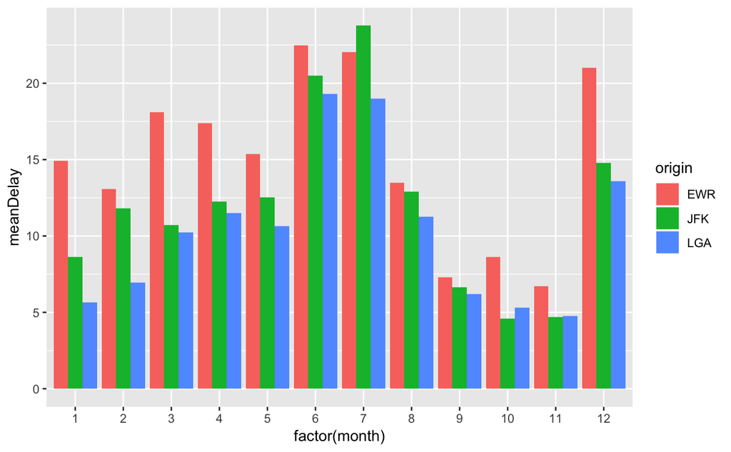

## Task Set 2: Facets and multiple geoms

1. Create a facetted version of any of the two histograms you made in the previous task set. You can pick a facet of your choice (remember that a facet should be a categorical variable)
2. The code below is the same as task 3 in the previous task set. Modify it to create a facetted version of the chart (instead of the stacked bars).

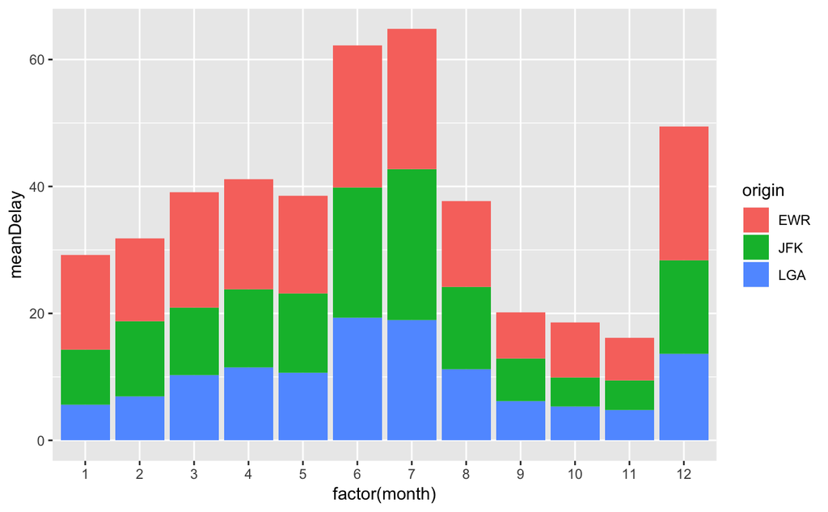

3. Extend the scatter plot you made in the previous section by adding a `geom_smooth()` to it that uses a linear model (method = “lm”).

## Task Set 3: Make a pretty plot

1. Take any plot that you made in any of the previous set of tasks and
   - Add axis labels and chart title
   - Any additional aesthetics to make it prettier
   - Choose a theme template (either from ggthemes or from ggplot)
   - Make any additional changes you would like to make it more attractive
2. Save this plot using `ggsave()` as a png and share it on the class4 channel.